## output: html_document

# Assignment: Prediction Assignment

# Background

The goal of your project is to predict the manner in which they did the exercise. This is the “classe” variable in the training set. You may use any of the other variables to predict with. You should create a report describing how you built your model, how you used cross validation, what you think the expected out of sample error is, and why you made the choices you did. You will also use your prediction model to predict 20 different test cases.

# Task

```r
library(lubridate)
library(AppliedPredictiveModeling)
library(forecast)
library(caret)
library(plyr)
library(gbm)
library(rpart)
library(rpart.plot)
library(randomForest)
library(rattle)
knitr::opts_chunk$set(cache=TRUE)
```

The training and testing data for the project are below:

```r
TrainUrl <- "https://d396qusza40orc.cloudfront.net/predmachlearn/pml-training.csv"
TestUrl <- "https://d396qusza40orc.cloudfront.net/predmachlearn/pml-testing.csv"
download.file(TrainUrl, destfile = "./course_8/pml-training.csv", method = "curl")
download.file(TestUrl, destfile = "./course_8/pml-testing.csv", method = "curl")

Training_data <- read.csv(TrainUrl, header = TRUE, na.strings = c("NA", "#DIV/0!",
    ""))
Testing_data <- read.csv(TestUrl, header = TRUE, na.strings = c("NA", "#DIV/0!",
    ""))
```

# Cleaning the data

We then clean the data: cleaining the data for NA and Zeros and Remove columns full of NAs.

```r
# cleaining the data for NA and Zeros Remove columns full of NAs.

new_testing <- names(Testing_data[, colSums(is.na(Testing_data)) == 0])[8:59]

Training_data <- Training_data[, c(new_testing, "classe")]
Testing_data <- Testing_data[, c(new_testing, "problem_id")]
```

# Partioning the training set

create test/ train data sets:

We will split our data into a training data set (75% of the total cases) and a testing data set (25% of the total cases).

```r
# str(Training_data) summary(Training_data)

set.seed(1234)
## create test/ train data sets

InTrain = createDataPartition(Training_data$classe, p = 0.75, list = FALSE)
training = Training_data[InTrain, ]
testing = Training_data[-InTrain, ]


dim(training)
```

```
## [1] 14718    53
```

```r
dim(testing)
```

```
## [1] 4904   53
```

# Classification tree as a model

```r
fit1 <- rpart(classe ~ ., data = training, method = "class")


# predict on test values
predtree <- predict(fit1, testing, type = "class")


# Confusion Matrix to test results:


confusionMatrix(predtree, testing$classe)
```

```
## Confusion Matrix and Statistics
##
##           Reference
## Prediction    A    B    C    D    E
##          A 1235  157   16   50   20
##          B   55  568   73   80  102
##          C   44  125  690  118  116
##          D   41   64   50  508   38
##          E   20   35   26   48  625
##
## Overall Statistics
##
##                Accuracy : 0.7394
##                  95% CI : (0.7269, 0.7516)
##     No Information Rate : 0.2845
##     P-Value [Acc > NIR] : < 2.2e-16
##
##                   Kappa : 0.6697
##  Mcnemar's Test P-Value : < 2.2e-16
##
## Statistics by Class:
##
##                      Class: A Class: B Class: C Class: D Class: E
## Sensitivity            0.8853   0.5985   0.8070   0.6318   0.6937
## Specificity            0.9307   0.9216   0.9005   0.9529   0.9678
## Pos Pred Value         0.8356   0.6469   0.6313   0.7247   0.8289
## Neg Pred Value         0.9533   0.9054   0.9567   0.9296   0.9335
## Prevalence             0.2845   0.1935   0.1743   0.1639   0.1837
## Detection Rate         0.2518   0.1158   0.1407   0.1036   0.1274
## Detection Prevalence   0.3014   0.1790   0.2229   0.1429   0.1538
## Balanced Accuracy      0.9080   0.7601   0.8537   0.7924   0.8307
```

# Random Forest Model:

```r
## Random Forest Model Train the model on the Split Training Data

rfmodel <- randomForest(classe ~ ., data = training)

# Use Model to predict on the Allocated Test Set

predrf <- predict(rfmodel, testing, type = "class")

# Create Confusion Matrix to Check Accuracy of Model
confusionMatrix(predrf, testing$classe)
```

```
## Confusion Matrix and Statistics
##
##           Reference
## Prediction    A    B    C    D    E
##          A 1394    3    0    0    0
##          B    1  944   10    0    0
##          C    0    2  843    6    0
##          D    0    0    2  798    0
##          E    0    0    0    0  901
##
## Overall Statistics
##
##                Accuracy : 0.9951
##                  95% CI : (0.9927, 0.9969)
##     No Information Rate : 0.2845
##     P-Value [Acc > NIR] : < 2.2e-16
##
##                   Kappa : 0.9938
##  Mcnemar's Test P-Value : NA
##
## Statistics by Class:
##
##                      Class: A Class: B Class: C Class: D Class: E
## Sensitivity            0.9993   0.9947   0.9860   0.9925   1.0000
## Specificity            0.9991   0.9972   0.9980   0.9995   1.0000
## Pos Pred Value         0.9979   0.9885   0.9906   0.9975   1.0000
## Neg Pred Value         0.9997   0.9987   0.9970   0.9985   1.0000
## Prevalence             0.2845   0.1935   0.1743   0.1639   0.1837
## Detection Rate         0.2843   0.1925   0.1719   0.1627   0.1837
## Detection Prevalence   0.2849   0.1947   0.1735   0.1631   0.1837
## Balanced Accuracy      0.9992   0.9960   0.9920   0.9960   1.0000
```

Final Predict Test:

```r
# Final Predict Test
predict(rfmodel, Testing_data, type = "class")
```

```
##  1  2  3  4  5  6  7  8  9 10 11 12 13 14 15 16 17 18 19 20
##  B  A  B  A  A  E  D  B  A  A  B  C  B  A  E  E  A  B  B  B
## Levels: A B C D E
```

# Graphs and figures

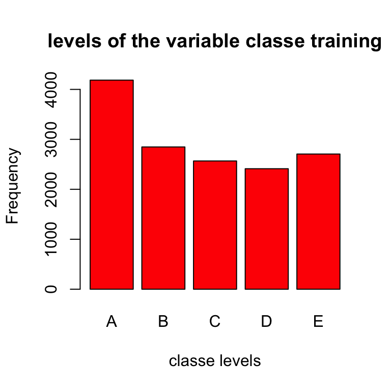

```r
plot(training$classe, col = "red", main = "levels of the variable classe training",
    xlab = "classe levels", ylab = "Frequency")
```

Decision Tree Model

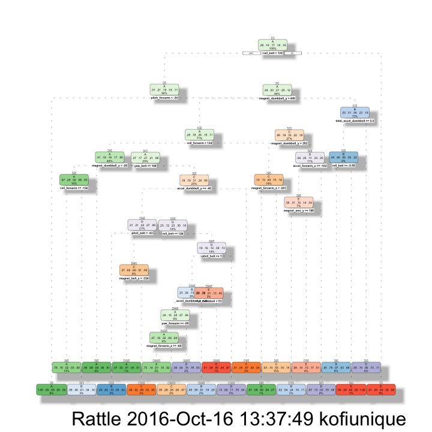

```r
## plot the classification tree
fancyRpartPlot(fit1)
```